# Compression panel optimization

## Goals

We were given the task of optimizing a compression panel so that it is as light as possible and doesn't fail below a certain threshold value of 30kN.

The free variables are as follow :

- Skin thickness
- Stringer thickness
- Stringer height
- Stringer width
- Number of stringers
- Rivet spacing

Since this is a lot of variables that can take any positive real values, a brute-force search of the design space would not be appropriate. Instead a **genetic algorithm** will be used.

## Numerical representation of compression panels

### Imports & Initial data entry

We start by importing **numpy** and **matplotlib**.

```python
import numpy as np
import matplotlib.pyplot as plt
```

Then dictionaries are created containing the properties of the material that can be used to build the compression panel.

```python
aluminium = {'density' : 2.78e3,    # [g/cm³]
             'EMod' : 72.4e9,      # [MPa]
             'StressMax' : 483e6,   # [MPa]
             'StressYield' : 385e6, # [MPa]
             'ID' : "Aluminium"}

steel = {'density' : 7.8e3,    # [g/cm³]
         'EMod' : 210e9,      # [MPa]
         'StressMax' : 1275e6,   # [MPa]
         'StressYield' : 1100e6, # [MPa]
         'ID' : "Steel"}

ForceBuckling = 15e3
ForceFailure = 30e3
Kc=3.2
```

### Panel creation and failure loading

We create a Panel class that will hold all of our parameters, as well as compute a few things.

The area, moment of inertia and weight of the panel are computed, which allow us to find the failure loads for skin and stringers, and tells us what fails first.

```python
class Panel:
    def __init__(self, **kwargs):
        # we use the passed arguments to define the panel
        self.w = 400e-3
        self.l = 500e-3
        self.tSkin = kwargs.get("t", 0.8e-3)
        self.tStringer = kwargs.get("tStringer", 1.5e-3)
        self.hStringer = kwargs.get("hStringer", 15e-3)
        self.wStringer = kwargs.get("wStringer", 15e-3)
        self.nStringer = kwargs.get("nStringer", 7)
        self.sRivet = kwargs.get("sRivet", 50e-3)
        self.matSkin =kwargs.get("matSkin", aluminium)
        self.matStringer = kwargs.get("matStringer", aluminium)

        # area of the panel is computed
        self.areaStringer = self.tStringer*(self.wStringer+(self.hStringer-self.tStringer))
        self.areaSkin = self.tSkin*self.w
        self.area = self.areaStringer*self.nStringer + self.areaSkin

        #stringer spacing is then computed
        self.bStringer = (self.w)/(self.nStringer-1)


        #centroid & moment of inertia computation
        t = self.tStringer
        c = self.wStringer-t
        b = self.hStringer
        a = self.wStringer
        self.yStringer =(t*(2*c+b)+c**2)/(2*(c+b))

        y = self.hStringer - self.yStringer
        self.IStringer = (1/3)*(t*y**3 +a*(b-y)**3 -(a-t)*(b-y-t)**3)

        # number of rivet computed, with check to make sure no rivets in the clamped area
        self.nRivet = (self.l)//(self.sRivet)
        if self.sRivet < 35e-3:
            self.nRivet-=2

        #weight of the panel is then computed including skin, stringers & rivets
        self.weight = self.areaStringer*self.nStringer*self.l*self.matStringer["density"] \
                    + self.areaSkin*self.l*self.matSkin["density"] \
                    + self.nRivet*self.nStringer*0.18222e-3


    def checkFailure(self):
        fSkin = 0
        fStringer = 0
        rivetBuckling = 0

        isIntact = [True, True] #skin, stringer
        area = self.area

        failureDict = {} #we create a failure dictionary


        # ultimate failure force for both stringer and skin
        failureDict["StringerFailure"] = self.matStringer["StressMax"]*area
        failureDict["SkinFailure"] = self.matSkin["StressMax"]*area

        # skin buckling
        stressPlateBuckling = Kc*self.matSkin["EMod"]*(self.tSkin/self.bStringer)**2
        failureDict["PlateBuckling"] = stressPlateBuckling*area

        # stringer buckling
        c=4
        Fcr = c*np.pi**2*self.matStringer["EMod"]*self.IStringer/((self.l)**2)
        failureDict["ColumnBuckling"] = Fcr*self.nStringer

        #rivet buckling
        c=2.1
        stressRivetBuckling = 0.9*c*self.matSkin["EMod"]*(self.tSkin/self.sRivet)**2
        rivetBuckling = stressRivetBuckling*area

        # we then find what the smallest failure is
        firstFail = min(failureDict, key=failureDict.get)

        # ultimate failure idk how that could happen
        if (firstFail == "StringerFailure" or firstFail =="SkinFailure") and failureDict["StringerFailure"] == failureDict["SkinFailure"]:
            return [[self.matSkin["StressMax"]*area, "SkinFailure"], [self.matStringer["StressMax"]*area, "StringerFailure"], [rivetBuckling, "RivetBuckling"]]

        # the skin fail first
        if firstFail == "PlateBuckling" or firstFail == "SkinFailure":
            area = self.areaStringer*self.nStringer
            isIntact = [False, True]
            fSkin = [failureDict[firstFail], firstFail]

            ultFailure = self.matStringer["StressMax"]*area

            if ultFailure < failureDict["ColumnBuckling"]:
                fStringer = [ultFailure, "StringerFailure"]
            else:
                fStringer = [failureDict["ColumnBuckling"], "ColumnBuckling"]

        # the stringers fail first
        elif firstFail == "ColumnBuckling" or firstFail == "StringerFailure":
            area = self.areaSkin
            isIntact = [True, False]
            fStringer = [failureDict[firstFail], firstFail]

            ultFailure = self.matSkin["StressMax"]*area
            fPlateBuckling = stressPlateBuckling*area

            if ultFailure < fPlateBuckling:
                fSkin = [ultFailure, "SkinFailure"]
            else:
                fSkin = [fPlateBuckling, "PlateBuckling"]

        return [fSkin, fStringer, [rivetBuckling, "rivetBuckling"]]

    def getParams(self):
        """
        returns parameters in order [t, tStringer, hStringer, wStringer, nStringer, self.sRivet, self.matSkin, self.matStringer]
        """
        return [self.tSkin, self.tStringer, self.hStringer, self.wStringer, self.nStringer, self.sRivet, self.matSkin, self.matStringer]
```

### Displaying information about a panel

While this class works to find failure loads, it's not easy for a human to read parameters from the object definition.

We therefore create two functions, **plotPanel** which draws the cross-section of a panel, and **pprint** which prints parameters, weight and failure loads in a way that is easier to read for us.

```python
def plotPanel(p):
    """
    Function takes a panel object and plot its cross section
    """
    baseCoord = (0,0)
    plt.figure(dpi=800)
    plt.axes()
    skin = plt.Rectangle((0, 0), p.w, p.tSkin, fc='b')
    plt.gca().add_patch(skin)

    step = (p.w - p.nStringer*p.wStringer)/(p.nStringer-1)
    for i in range(int(p.nStringer)):
        y = p.tSkin
        if i/(p.nStringer) >= 0.5:
            x = i*(step)+i*(p.wStringer)
            x2 = x+ p.wStringer - p.tStringer
            y2 = p.tSkin + p.tStringer

        else:
            x = i*(step+p.wStringer)
            x2 = x
            y2 = p.tSkin + p.tStringer

        stringer = plt.Rectangle((x,y), p.wStringer, p.tStringer, fc="r")
        plt.gca().add_patch(stringer)

        stringer2 = plt.Rectangle((x2,y2), p.tStringer, p.hStringer-p.tStringer, fc="r")
        plt.gca().add_patch(stringer2)

    plt.axis('scaled')
    plt.axis('off')
    plt.axis([0, 0.40, -0.02, 0.02])
    plt.show()

def pprint(panel):
    """
    Simple prettyprint function that takes a panel object and prints out info about it
    """
    params=panel.getParams()
    fail = panel.checkFailure()
    print("""
The panel has a mass of {}g
The skin fails at {} kN because of {}
The stringer fail at {} kN because of {}

There is rivet buckling at {} kN

The skin thickness is {} mm
The stringer dimensions are :
    height    - {} mm
    width     - {} mm
    thickness - {} mm

There is {} stringers
Rivet spacing is {} mm

The skin is made of {}
The stringers are made of {}
""".format(round(panel.weight*1e3), round(fail[0][0]*1e-3,1), fail[0][1], round(fail[1][0]*1e-3,1), fail[1][1], round(fail[2][0]*1e-3,1), round(params[0]*1e3,3),
           round(params[2]*1e3,2),round(params[3]*1e3,2),round(params[1]*1e3,2), params[4],
           round(params[5]*1e3,3), params[6]["ID"], params[7]["ID"]))
```

### Verifiying our code

```
The panel has a mass of 738g
The skin fails at 17.4 kN because of PlateBuckling
The stringer fail at 51.0 kN because of ColumnBuckling

There is rivet buckling at 16.3 kN

The skin thickness is 0.8 mm
The stringer dimensions are :
    height    - 15.0 mm
    width     - 15.0 mm
    thickness - 1.0 mm

There is 7 stringers
Rivet spacing is 53.0 mm

The skin is made of Aluminium
The stringers are made of Aluminium
```

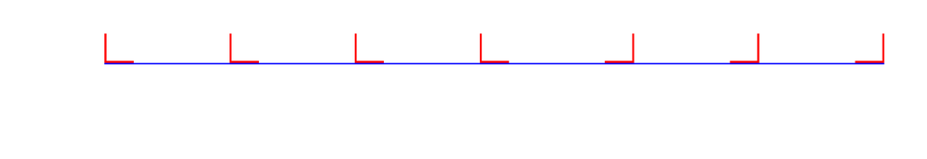

```
The panel has a mass of 932g
The skin fails at 15.4 kN because of PlateBuckling
The stringer fail at 153.6 kN because of ColumnBuckling

There is rivet buckling at 8.1 kN

The skin thickness is 0.8 mm
The stringer dimensions are :
    height    - 20.0 mm
    width     - 20.0 mm
    thickness - 1.5 mm

There is 6 stringers
Rivet spacing is 85.0 mm

The skin is made of Aluminium
The stringers are made of Aluminium
```

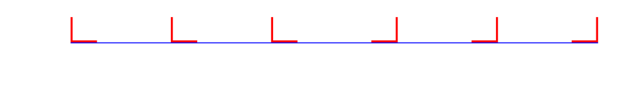

```python
params = {"t" : 0.8e-3,
          "tStringer" : 1e-3,
         "hStringer" : 15e-3,
         "wStringer" : 15e-3,
         "nStringer" : 7,
         "sRivet" : 53e-3,
          "matSkin" : aluminium,
          "matStringer" : aluminium}

newPanel=Panel(**params)

pprint(newPanel)
plotPanel(newPanel)

params = {"t" : 0.8e-3,
          "tStringer" : 1.5e-3,
         "hStringer" : 20e-3,
         "wStringer" : 20e-3,
         "nStringer" : 6,
         "sRivet" : 85e-3,
          "matSkin" : aluminium,
          "matStringer" : aluminium}

oldPanel=Panel(**params)
pprint(oldPanel)
plotPanel(oldPanel)
```

## Genetic algorithm & optimization

### Random panel creation

We start by creating a function **getRandomParams** that created a random dictionary of parameters that can be used to create a completery random panel, bounded by the values we chose for our design space.

```python
#bounds of the design space
# bounds[0] = skin thickness
# bounds[1] = stringer thickness
# bounds[2] = stringer height
# bounds[3] = stringer width
# bounds[4] = number of stringers
# bounds[5] = rivet spacing
bounds = [[0.3e-3,10e-3], [0.8e-3,5e-3], [5e-3,100e-3], [5e-3,40e-3], [2,10], [10e-3, 100e-3]]

def getRandomParams():
    t = -1*np.random.uniform(-bounds[0][1], -bounds[0][0])
    hStringer = -1*np.random.uniform(-bounds[2][1], -bounds[2][0])
    wStringer = -1*np.random.uniform(-bounds[3][1], -bounds[3][0])
    tStringer = -1*np.random.uniform(-bounds[1][1], -bounds[1][0])
    sRivet = -1*np.random.uniform(-bounds[5][1], -bounds[5][0])
    nStringer = np.random.randint(bounds[4][0], bounds[4][1]+1)
    params = {"t" : t,
          "tStringer" : tStringer,
         "hStringer" : hStringer,
         "wStringer" : wStringer,
         "nStringer" : nStringer,
         "sRivet" : sRivet,
         "matSkin" : aluminium,
         "matStringer" : aluminium}
#           "matSkin" : np.random.choice([aluminium, steel]),
#           "matStringer" : np.random.choice([aluminium, steel])}

    return params
```

### Genetic algorithm functions construction

#### Fitness function

The fitness function works as follow :

1. The panel's failure loads are computed, to make sure they are above the minimal requirements, if not fitness is set to infinity
2. If the requirements are satisfied, the fitness is defined as the weight

#### Parent selection function

Tournament selection is used

#### Crossover

Whole arithmetic recombination is used

#### Mutation

A non-uniform mutation function with gaussian distribution is used

#### Killing function

```python
import random
from operator import itemgetter

def fitness(panel):
    #the fitness function work as follow :
    # if the load constraints are not respect > fitness = infinity
    # if the load constraints are respected > fitness = weight
    values = panel.checkFailure()

    fBuckle = min(values[0][0], values[1][0])
    fFailure = max(values[0][0], values[1][0])
    fRivet = values[2][0]

    if fBuckle < 15e3 or fFailure < 30e3 or fRivet <10e3:
        return np.inf
    penalty = max(panel.hStringer/panel.wStringer, panel.wStringer/panel.hStringer)
    return panel.weight

def selection(population, K=50):
    # tournament selection
    # we start by picking K chromosomes randomly
    # then from those K samples, the one with minimal fitness is picked and returned
    """
    We expect the population to be a 2D list of the following format:
    [[fitness, PanelObject],
     [fitness2, PanelObject2],
     ...
     n times for the whole population
     ...
     [fitnessN, PanelObjectN]]
    """
    candidates = []
    random.shuffle(population)

    for i in range(K):
        candidates.append(population.pop())

    return sorted(candidates, key=itemgetter(0))[0]


def crossover(panel1, panel2, Pc=0.75, alpha=0.4):
    # There is a Pc chance that crossover will happen
    # otherwise asexual selection is applied (both parents are returned)
    if np.random.uniform() > Pc:
        return panel1, panel2

    # whole arithmetic recombination is used
    # child1 gets alpha % of parent1 allele and (1-alpha)% of parent2 gallele
    # child2 gets the opposite

    params1 = panel1.getParams()
    params2 = panel2.getParams()
    childList = []
    for i in range(2):
        t = alpha*params1[0]+(1-alpha)*params2[0]
        tStringer = alpha*params1[1]+(1-alpha)*params2[1]
        hStringer = alpha*params1[2]+(1-alpha)*params2[2]
        wStringer = alpha*params1[3]+(1-alpha)*params2[3]
        nStringer = round(alpha*params1[4]+(1-alpha)*params2[4])
        sRivet = alpha*params1[5]+(1-alpha)*params2[5]

        params = {"t" : t,
                  "tStringer" : tStringer,
                 "hStringer" : hStringer,
                 "wStringer" : wStringer,
                 "nStringer" : nStringer,
                 "sRivet" : sRivet}

        childList.append(Panel(**params))
        alpha = 1-alpha

    return childList[0], childList[1]

def mutation(panel, Pm=0.25, stdev=0.15):
    params = panel.getParams()

    # there is a Pm chance for each gene in the genome that the allele will be modified
    chance = np.random.uniform(size=len(params))
    for i in range(len(params)):
        if chance[i] > Pm:
            continue

        # Allele mutation work as follow :
        # A random numerical value is picked from a gaussian distribution with mean 0 and
        # standard deviation defined as a % of the range of allowed values for said allele
        # the mutation value (can be positive or negative) is then added to the allele
        # which is clipped to remain in the range of allowed values
        if i in [0,1,2,3,5]:
            params[i] = np.clip(params[i]+np.random.normal(0, scale=(bounds[i][1]-bounds[i][0])*stdev), bounds[i][0], bounds[i][1])
        if i == 4:
            params[i] = round(np.clip(params[i]+np.random.normal(0, scale=1), bounds[i][0], bounds[i][1]))
    params = {"t" : params[0],
            "tStringer" : params[1],
            "hStringer" : params[2],
            "wStringer" : params[3],
            "nStringer" : params[4],
            "sRivet" : params[5]}
    return Panel(**params)

def kill(population,K=100):
    # Same tournament selection that was used for parent selection
    # Except the less fit chromosome are preferred
    # returns the population minus the chromosome killed
    candidates = []
    random.shuffle(population)

    for i in range(K):
        candidates.append(population.pop())

    sorted(candidates, key=itemgetter(0))
    candidates.pop(-1)
    population.extend(candidates)
    return sorted(population, key=itemgetter(0))
```

### Putting the pieces together

Now that we have our fitness, selection, crossover and mutation functions we can finally build the genetic algorithm !

1. We start by populating a list with sPop random panels.
2. We then perform nIter cycles of crossover, mutation and survivor selection,
3. The resulting population is ordered, the best panel is picked and the algorithm starts over nRun times
4. The best panel out of the best panels for each run is our optimal panel.

The user parameters are :

- nIter - number of iterations
- sPop - size of the population
- nRun - number of times the algorithm should be run
- K - Number of random samples drawn for tournament selection
- Pm - probability that each parameter is going to be mutated
- tau - not in use, basically a tuning parameter that decreases Pm over the number of iterations to avoid big jumps
- Pc - probability that crossover will happen, otherwise the parents are returned as child (duplication)
- Alpha - parameter used for whole arithmetic recombination, read crossover code for detail
- stdev - Which % of the range of allowed valued for a gene should be used a standard deviation for mutation function

```python
nIter = 5000
sPop = 1000
nRun = 20

K = 100
Pm = 0.25
tau = np.inf
Pc = 0.9
alpha = 0.35
stdev=0.15


meanArray = []
bestArray = []
solutionList = []

for j in range(nRun):
    meanFit = []
    bestFit = []
    population = []

    #initial population
    for i in range(sPop):
        params = getRandomParams()
        panel = Panel(**params)
        population.append([fitness(panel),panel])

    for i in range(nIter):
    #     Pm = Pm_i*np.exp(-i/tau)

        #we start by picking two "parents" based on their fitness
        parent1 = selection(population[:], K=K)
        parent2 = selection(population[:], K=K)

        # we produce two child with our crossover function
        child1, child2 = crossover(parent1[1], parent2[1], Pc=Pc, alpha=alpha)

        # they are then mutated a bit
        child1 = mutation(child1, Pm=Pm, stdev=stdev)
        child2 = mutation(child2, Pm=Pm, stdev=stdev)
        # and we add them to the population
        population.extend([[fitness(child1), child1],[fitness(child2),child2]])

        #we kill two panels so that the population remain constant
        population = kill(population, K=K)
        population = kill(population, K=K)

        #data logging for later analysis
        if i%(nIter/1000):
            population = sorted(population, key=itemgetter(0))
            fit = np.array([i[0] for i in population])
            meanFit.append(np.mean(fit[fit<1e308]))
            bestFit.append(population[0][0])
        #print % of progress
#         if i%(nIter/4)==0:
#             print(100*(i/nIter))

    meanArray.append(meanFit)
    bestArray.append(bestFit)
    solutionList.append(population[0])
#     print(j)
```

### Finding the best panel

After the algorithm has finished running we can find which panel is the best !

```python
# we sort the list of solution and print the best panel of all the runs
solutionList = sorted(solutionList, key=itemgetter(0))
bestPanel = solutionList[0][1]
pprint(bestPanel)
```

```
The panel has a mass of 540.0g
The skin fails at 15.2 kN because of PlateBuckling
The stringer fail at 30.4 kN because of ColumnBuckling

There is rivet buckling at 10.1 kN

The skin thickness is 0.661 mm
The stringer dimensions are :
    height    - 11.39 mm
    width     - 5.0 mm
    thickness - 0.8 mm

There is 9.0 stringers
Rivet spacing is 47.29 mm

The skin is made of Aluminium
The stringers are made of Aluminium
```

### Understanding the algorithm & Plotting

To get a look inside the algorithm we plot for each run the mean fitness of the population and the best fitting panel.

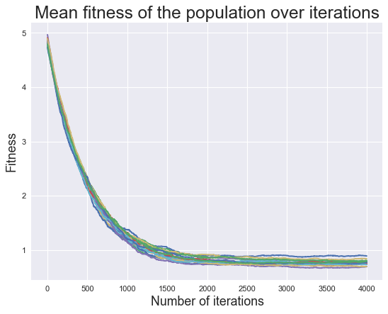

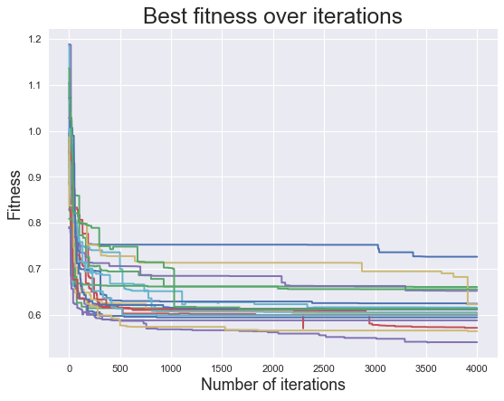

```python
#basic plotting to show how the population evolves over tie
plt.style.use("seaborn")
plt.figure(figsize=(8,6), dpi=80)
plt.title("Mean fitness of the population over iterations",size=22)
plt.ylabel("Fitness",size=16)
plt.xlabel("Number of iterations", size=16)

for i in meanArray:
    plt.plot(range(0,4000), i)
plt.savefig("MeanFit")

plt.figure(figsize=(8,6), dpi=80)
plt.title("Best fitness over iterations",size=22)
plt.ylabel("Fitness",size=16)
plt.xlabel("Number of iterations", size=16)

for i in bestArray:
    plt.plot(range(0,4000), i)
plt.savefig("BestFit")
```

### Best panel drawing

We finish by drawing the best panel to get a sense of what its cross-section would look like.

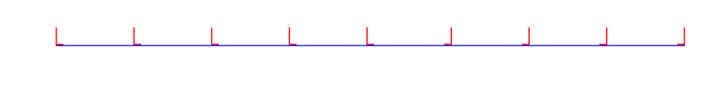

```python
plotPanel(bestPanel)
```